# Baltimore Ceasefire 365: Estimated impact of a recurring grassroots ceasefire on gun violence

Data from January 1, 2012 to June 13, 2019

Baltimore Ceasefire 365 is a city-wide call asking Baltimore residents to avoid having any murders through quarterly Ceasefires and Peace Challenges (February, May, August, and November).

We use open data and the R programming language to look at the distribution of shootings in time and model the impact of the Ceasefires.

## Shootings in Baltimore

Baltimore releases detailed data on issues relevant to the city, including crime. We begin by graphing the raw numbers of shootings, plotted for each day.

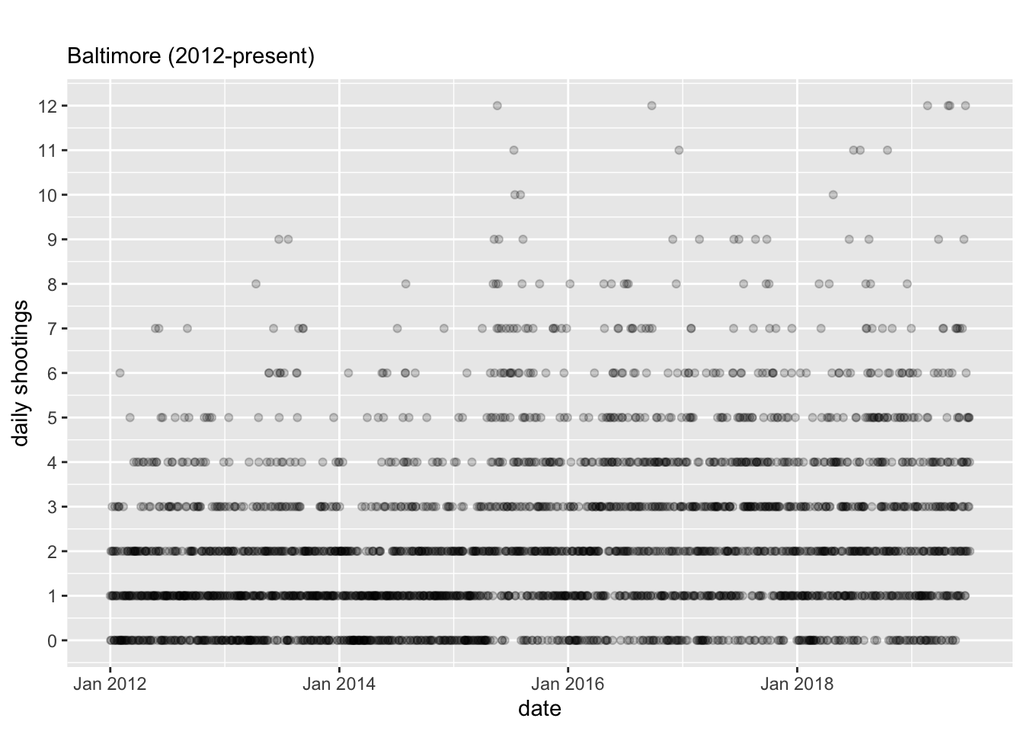

```r
library(knitr)
library(tidyverse)
library(scales)

bpd <- read_csv("https://raw.githubusercontent.com/peterphalen/ceasefire/master/BPD_Part_1_Victim_Based_Crime_Data.csv")

# subset to shootings or homicides with a firearm
bpd <- subset(bpd, Description == "SHOOTING" |
                (Description == "HOMICIDE" & Weapon == "FIREARM"))

bpd$CrimeDate <- as.Date(bpd$CrimeDate, format = "%m/%d/%Y")

# there are many crimes per day. collapse to daily counts
daily <- bpd %>% group_by(CrimeDate) %>% summarise(shootings = n())

# fill missing dates, because some had no shootings
full.ts <- data.frame(CrimeDate = seq(daily$CrimeDate[1],
                                      daily$CrimeDate[nrow(daily)], by="day"))
daily <- full_join(full.ts,daily)
daily <- daily %>% group_by(CrimeDate) %>% mutate_all(funs(ifelse(is.na(.),0,.)))

ggplot(daily) +
  aes(x=CrimeDate, y=shootings) +
  geom_point(alpha=.2) +
  xlab("date") +
  ylab("daily shootings") +
  scale_y_continuous(breaks=0:20) +
  scale_x_date(labels = date_format("%b %Y")) +
  ggtitle(" ",
          subtitle="Baltimore (2012-present)")
```

## Ceasefire weekends

Ceasefires have been called four times per year since August 2017. These always occur on the first weekends (Friday through Sunday) of February, August, and November, as well as Mother's Day weekend in May.

```r
# first day (Friday) of ceasefire weekends
ceasefire.initial <-
  as.Date(
  c("08/04/2017",
    "11/03/2017",
    "02/02/2018",
    "05/11/2018",
    "08/03/2018",
    "11/02/2018",
    "02/01/2019",
    "05/10/2019",
    "08/02/2019"),
      format="%m/%d/%Y")

ceasefire.weekends <-
  lapply(ceasefire.initial,
         function(x){
           seq(from=x,
               by="day",
               length.out=3)
           }
         )
ceasefire.weekends <- do.call("c",
                              ceasefire.weekends)
```

## Statistical model

We want to include information about the date, the day of the week (Mon-Sun), the day of the year (to measure the effects of seasons and “special days” like Christmas), and a binary variable indicating whether a date occurs during ceasefire. We create those variables here:

```r
library(lubridate)

# the julian calendar is a simple system for numeric dates
daily$jul <- julian(daily$CrimeDate)

daily$weekday <- factor(weekdays(daily$CrimeDate),
                        levels=c("Monday","Tuesday","Wednesday","Thursday",
                                 "Friday","Saturday","Sunday"))

daily$seasonal <- yday(daily$CrimeDate)

daily$day.of.year <- date_format("%b-%d")(daily$CrimeDate)


daily$ceasefire <- factor(ifelse(daily$CrimeDate %in% ceasefire.weekends, 1, 0),
                          labels=c("Regular Day","Ceasefire Weekend"))
```

We also need to identify Mother’s Day, because it floats (second Sunday in May) but always coincides with a ceasefire. This code identifies each Mother’s Day in the dataset.

```r
d <- daily$CrimeDate
sundays.in.may <- d[ format(d, '%a') == 'Sun' & format(d, '%B') == 'May' ]
d <- data.frame(sundays = sundays.in.may, year = format(sundays.in.may, '%Y'))
mothers.days <-
  d %>%
  group_by(year) %>%
  mutate(week2 = sundays[2]) %>%
  distinct(week2) %>%
  pull(week2)

daily$mothers.day <- factor(ifelse(daily$CrimeDate %in% mothers.days, 1, 0))
```

You can see that there were a lot of shootings on Mother’s Days in the years prior to Ceasefire, but since the introduction of Ceasefire there have been very few.

```r
print(daily %>% subset(mothers.day == 1))
```

```
## # A tibble: 8 x 8
## # Groups:   CrimeDate [8]
##   CrimeDate  shootings   jul weekday seasonal day.of.year ceasefire
##   <date>         <dbl> <dbl> <fct>      <dbl> <chr>       <fct>
## 1 2012-05-13         4 15473 Sunday       134 May-13      Regular …
## 2 2013-05-12         2 15837 Sunday       132 May-12      Regular …
## 3 2014-05-11         2 16201 Sunday       131 May-11      Regular …
## 4 2015-05-10         9 16565 Sunday       130 May-10      Regular …
## 5 2016-05-08         2 16929 Sunday       129 May-08      Regular …
## 6 2017-05-14         2 17300 Sunday       134 May-14      Regular …
## 7 2018-05-13         0 17664 Sunday       133 May-13      Ceasefir…
## 8 2019-05-12         1 18028 Sunday       132 May-12      Ceasefir…
## # … with 1 more variable: mothers.day <fct>
```

We’ll predict shootings using the following covariates:

- Spline time trend
  - splines are estimated to allow for “curvy” relationships while avoiding overfitting
- Cyclical spline for yearly seasonality
  - the cyclical constraint requires the seasonal effect to begin where it ended
- Random effects for day of the week
  - we allow intercepts to vary for days of the week in case weekends have different patterns of shootings than weekdays
- Random effects for each day of the year
  - we allow varying intercepts for each day of the year in case “special days”, like Christmas, show different patterns of shootings
- Binary indicator for Mother’s Day
  - Second Sunday in May, and always coincides with ceasefire.
- Binary indicator for the ceasefire
  - to estimate the impact of ceasefire after accounting for all of the above

We use a Poisson link function because the outcome is a count and the `mean` is about the same as `sd`.

We fit the model using the `rstanarm` package.

```r
library(rstanarm)

model <- stan_gamm4(shootings ~
            s(jul) + # spline time trend
            s(seasonal, # seasonal effect
             bs="cc") + #cyclical constraint
            mothers.day + # mothers day indicator
            ceasefire, # ceasefire indicator
           random= ~ (1 | weekday) + # day of the week
                     (1 | day.of.year), # every day....
           data=daily,
           cores=4,
           adapt_delta=.975,
           iter=2000,
           family=poisson)
```

The following code creates a plot of the model against the observations. The red line represents the average. The grey area is the 80% predictive interval, which means that about 80% of days will have shooting counts that fall within the grey area. 10% of the time, the number of shootings will extend **above** the grey area.

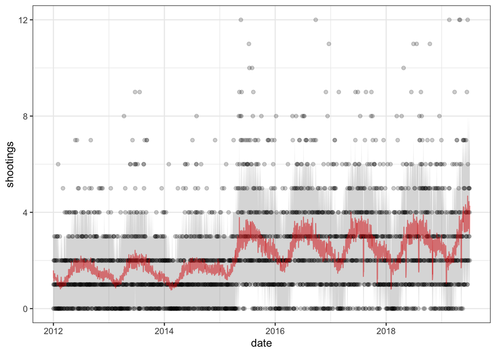

```r
daily$Estimate <- apply(posterior_linpred(model, transform=TRUE),
                        2, median)

# 80% posterior predictive interval for main plot
preds <- posterior_predict(model, transform=TRUE)
preds <- apply(preds, 2, function(x){quantile(x, prob=c(.1, .9))})

daily$high <- preds["90%",]
daily$low <- preds["10%",]

daily %>%
  ggplot(aes(x = CrimeDate, y = shootings)) +
  geom_point(alpha=.2) +
  geom_line(aes(y = Estimate), alpha=.5, color="red") +
  geom_ribbon(aes(ymin=low, ymax=high), alpha=.2) +
  scale_y_continuous(breaks=c(0,4,8,12)) +
  xlab("date") +
  theme_bw()
```

Ceasefires are visible as eight dramatic downward red spikes beginning in 2017.

#### Model components

We can plot the marginal effects to show the components that make up the above time series. The specific numbers of shootings are to some extent dependent upon the reference point, but these figures give you the right idea of the shape of the trends.

We begin by creating a plot of the overall time trend, with seasonality removed.

```r
### Time trend plot
time.frame <- with(daily, # Ref: August
                  data.frame(
                    jul=jul,
                    weekday=0, # not used for this prediction
                    ceasefire="Regular Day",
                    day.of.year="Aug-01",
                    mothers.day = 0,
                    seasonal=yday(as.Date("2018-08-01"))))

post <- posterior_linpred(model,
                          newdata=time.frame,
                          transform=TRUE,
                          re.form = NA)
time.frame$Estimate <- apply(post,2, median)

# 95% CI
ci <- apply(post,2,function(x){quantile(x, prob=c(.025, .975))})
time.frame$low <- ci["2.5%",]
time.frame$high <- ci["97.5%",]

trend.axis.dates <- seq(from=as.Date("2012-01-01"),
                        by="year",
                        length.out=9)
time.plot <-
  time.frame %>%
  ggplot() +
  aes(x=jul, y=Estimate) +
  geom_line(aes(y = Estimate), alpha=.5) +
  geom_ribbon(aes(ymin=low, ymax=high), alpha=.2) +
  xlab("Time trend") +
  ylab("Shootings") +
  ggtitle(" ") +
  scale_x_continuous(
    breaks=julian(trend.axis.dates),
    labels=date_format("%m-%Y")(trend.axis.dates)) +
  theme_bw()
```

Here’s the deseasonalized time trend we just created in the above block of code. Shootings increased sometime in 2014-2015 and have stayed high.

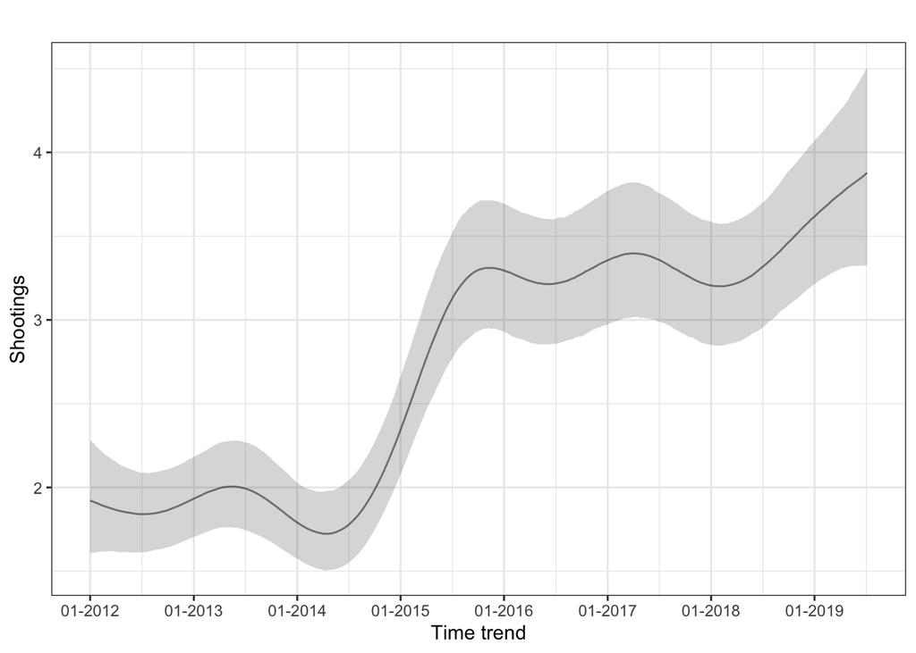

```r
time.plot
```

Now we’re going to construct plots for all the other component.

```r
###################
## day of year plot

doy.for.single.year <- date_format("%b-%d")(seq(as.Date("0000-01-01"), as.Date("0000-12-31"), by = 1))
exact.day.frame <- with(daily, # Ref: regular day in mid-2018
                data.frame(
                  jul=julian(as.Date("2018-08-01"))[1],
                  weekday=0, # weekday not used for this prediction
                  ceasefire="Regular Day",
                  mothers.day = 0,
                  doy.index = 1:length(doy.for.single.year),
                  day.of.year=doy.for.single.year,
                seasonal=100))

doy.samples <- as.matrix(model, regex_pars = " day.of.year")

doy.effects <- apply(doy.samples,2, median)
# scale to an IRR by exponentiating
doy.effects <- exp(doy.effects)
exact.day.frame$Estimate <- as.vector(doy.effects)

# 95% credible intervals (exponentiated)
ci <- exp(apply(doy.samples,2,function(x){quantile(x, prob=c(.025, .975))}))
exact.day.frame$low <- ci["2.5%",]
exact.day.frame$high <- ci["97.5%",]

doy.axis.dates <- seq(as.Date("0-01-01"),by="month",length.out=12)

largest.day <- which.max(exact.day.frame$Estimate)
largest.day.row <- exact.day.frame[largest.day,]

lowest.day <- which.min(exact.day.frame$Estimate)
lowest.day.row <- exact.day.frame[lowest.day,]

xmas.day <- exact.day.frame[which(exact.day.frame$day.of.year=="Dec-25"),]

doy.plot <-
  exact.day.frame %>%
  ggplot() +
  aes(x=doy.index, y=Estimate) +
  geom_line(aes(y = Estimate), alpha=.5) +
  geom_ribbon(aes(ymin=low, ymax=high), alpha=.2) +
  xlab("Day of year") +
  ylab("Shootings\n(incidence rate ratio)") +
  ggtitle(" ") +
  scale_x_continuous(
    breaks=yday(c(doy.axis.dates, as.Date("0-12-31"))),
    labels=date_format("%b-%d")(c(doy.axis.dates, as.Date("0-01-01")))
  ) +
  #highest day
  annotate("text", x = largest.day.row$doy.index,
           y = largest.day.row$Estimate + .3,
           label = paste("largest increase:",largest.day.row$day.of.year)) +
  geom_segment(aes(
               xend = largest.day.row$doy.index,
               x = largest.day.row$doy.index + 5,
               yend = largest.day.row$Estimate + .02,
               y = largest.day.row$Estimate + .26),
               arrow = arrow(length = unit(0.5, "cm"))) +
  # lowest day
  annotate("text", x = lowest.day.row$doy.index - 20,
           y = lowest.day.row$Estimate - .25,
           label = paste("largest decrease:",lowest.day.row$day.of.year)) +
  geom_segment(aes(
               xend = lowest.day.row$doy.index,
               x = lowest.day.row$doy.index - 6,
               yend = lowest.day.row$Estimate - .02,
               y = lowest.day.row$Estimate - .22),
               arrow = arrow(length = unit(0.5, "cm"))) +
  # christmas day
  annotate("text", x = xmas.day$doy.index - 55,
           y = xmas.day$Estimate + .33,
           label = "Christmas day (Dec 25th)") +
  geom_segment(aes(
               xend = xmas.day$doy.index - 3,
               x = xmas.day$doy.index - 40,
               yend = xmas.day$Estimate + .02,
               y = xmas.day$Estimate + .28),
               arrow = arrow(length = unit(0.5, "cm"))) +
  theme_bw()

###################
## yearly seasonal plot
seasonal.frame <- with(daily, # Ref: regular day in mid-2018
                data.frame(
                  jul=julian(as.Date("2018-08-01"))[1],
                  weekday=0, # weekday not used for this prediction
                  ceasefire="Regular Day",
                  mothers.day = 0,
                  day.of.year=0,
                  seasonal=1:365))

post <- posterior_linpred(model,
                           newdata=seasonal.frame,
                           transform=TRUE,
                          re.form = NA)
seasonal.frame$Estimate <- apply(post,2, median)

# 95% CI
ci <- apply(post,2,function(x){quantile(x, prob=c(.025, .975))})
seasonal.frame$low <- ci["2.5%",]
seasonal.frame$high <- ci["97.5%",]

doy.axis.dates <- seq(as.Date("0-01-01"),by="month",length.out=12)

seasonal.plot <-
  seasonal.frame %>%
  ggplot() +
  aes(x=seasonal, y=Estimate) +
  geom_line(aes(y = Estimate), alpha=.5) +
  geom_ribbon(aes(ymin=low, ymax=high), alpha=.2) +
  xlab("Seasonal trend") +
  ylab("Shootings") +
  ggtitle(" ") +
  scale_x_continuous(
    breaks=yday(c(doy.axis.dates, as.Date("0-12-31"))),
    labels=date_format("%b")(c(doy.axis.dates, as.Date("0-01-01")))
  ) +
  theme_bw()

###################
## Day of week plot

wday.frame <- with(daily, # Ref: regular day in August 2018
                  data.frame(
                    jul=julian(as.Date("2018-08-01"))[1],
                    weekday=unique(daily$weekday),
                    ceasefire="Regular Day",
                    mothers.day = 0,
                    day.of.year=yday(as.Date("2018-08-01")),
                    seasonal=yday(as.Date("2018-08-01"))))

post <- posterior_linpred(model,
                          newdata=wday.frame,
                          transform=TRUE)
wday.frame$Estimate <- apply(post,2, median)

# 95% CI
ci <- apply(post,2,function(x){quantile(x, prob=c(.025, .975))})
wday.frame$low <- ci["2.5%",]
wday.frame$high <- ci["97.5%",]

wday.plot <-
  wday.frame %>%
  ggplot() +
  aes(x=weekday, y=Estimate) +
  geom_point(size=2) +
  geom_errorbar(aes(ymin=low, ymax=high),
                width=.2) +
  xlab("Day of week") +
  ylab("Shootings") +
  ggtitle(" ") +
  theme_bw()
```

Here’s the day-of-year plot we just constructed. We don’t see a lot of evidence for day-of-year effects: the 95% credible intervals for all these days overlap. So we could make an argument for taking it out of the model, but including it lends credence to the idea that the ceasefire effect is special.

I’ve programmatically marked the highest and lowest days (after accounting for slower-moving seasonal trends) on the following figure. I’ve also marked Christmas day, because it was interesting to me.

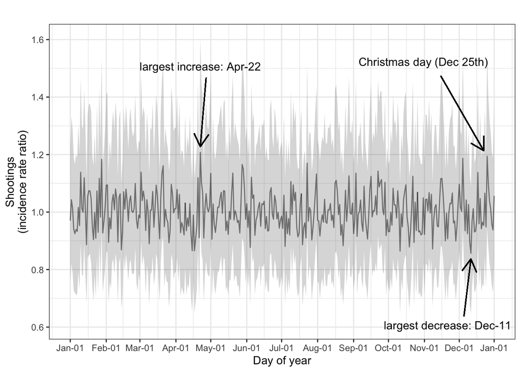

```r
doy.plot
```

Here are the 5 days with the lowest numbers of shootings (relative to their placement in the season).

```r
day.effects.sorted <- exact.day.frame[order(exact.day.frame$Estimate),
                                        "day.of.year"]
kable(data.frame(five_lowest_days=head(day.effects.sorted,5)))
```

| five_lowest_days |
| --- |
| Dec-11 |
| Oct-11 |
| Apr-17 |
| Apr-15 |
| Feb-14 |

And here are the 5 days with highest numbers of shootings (relative to their placement in the season).

Christmas day is the second highest day.

The other dates are not holidays. It’s likely these effects are simply statistical noise…

```r
kable(data.frame(five_highest_days=rev(tail(day.effects.sorted,5))))
```

| five_highest_days |
| --- |
| Apr-22 |
| Dec-25 |
| Dec-04 |
| Jan-28 |
| Jul-23 |

We do see a strong seasonal effect, with summers showing up as particularly bad. We see the largest dips in shootings in February and March, cold and dark months in Baltimore.

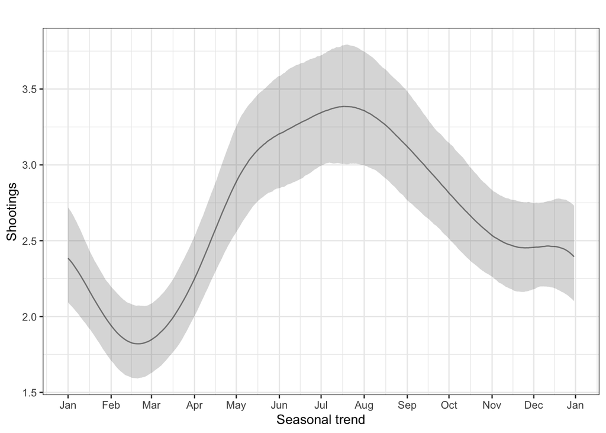

```r
seasonal.plot
```

There is essentially no weekday effect.

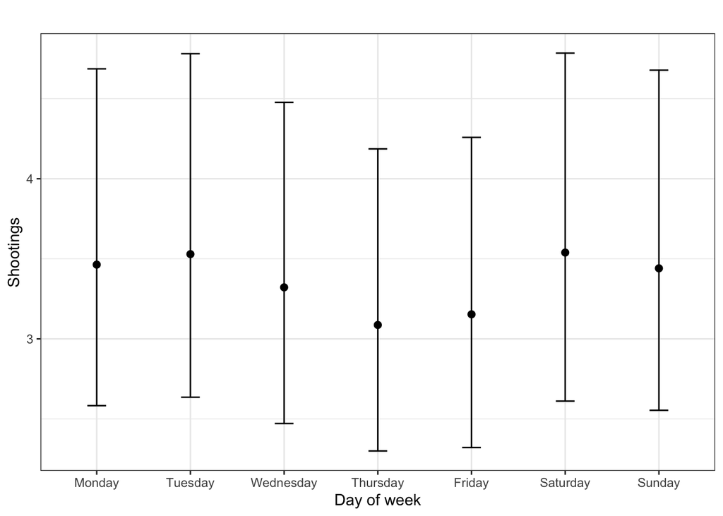

```r
wday.plot
```

## Effect of Ceasefire

Finally, we can use this model to measure the effect of Ceasefires on shootings per day, after accounting for all these trends and seasonalities. The effect of the Ceasefire (plotted here as an incidence rate ratio with 95% credible intervals) is classically statistically significant.

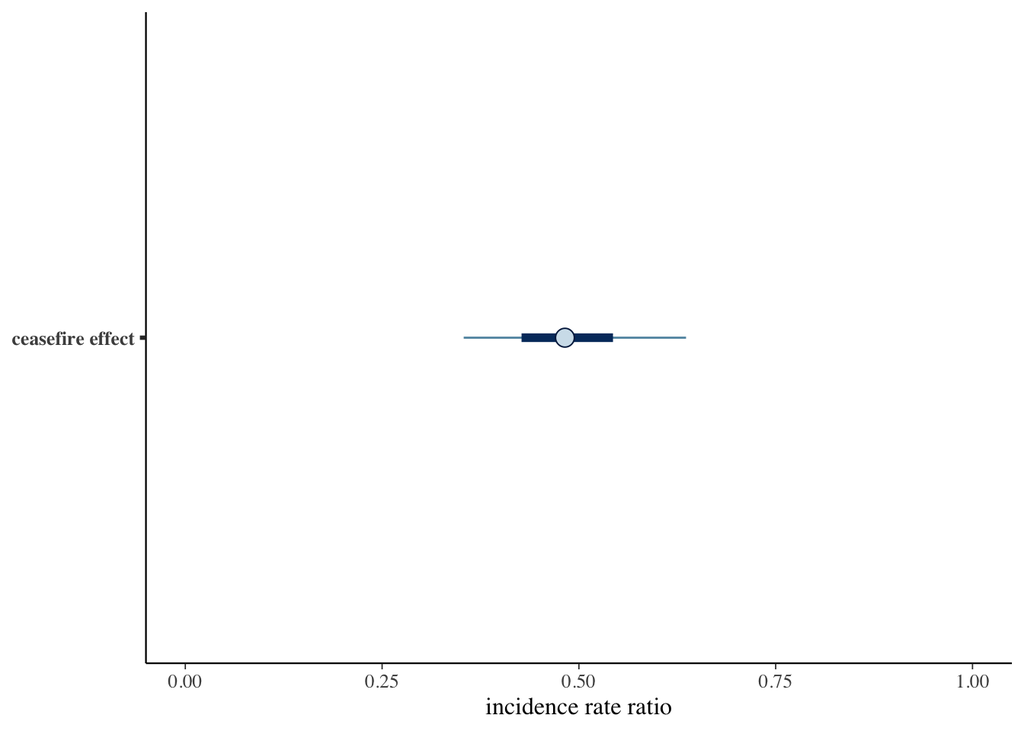

```r
ceasefire.effect <- as.array(model, regex_pars = "ceasefire")
# scale to an IRR by exponentiating
ceasefire.effect <- exp(ceasefire.effect)
library(bayesplot)
mcmc_intervals(ceasefire.effect) +
  scale_y_discrete(labels="ceasefire effect") +
  xlab("incidence rate ratio") +
  xlim(c(0,1))
```

We’re looking at an approximate 50% reduction in shootings during ceasefire weekends, after accounting for all other effects (e.g., day of the week, holidays, etc).

```r
round(1-median(ceasefire.effect),2)
```

```
## [1] 0.52
```

There’s enough uncertainty in our estimates that the true effect of ceasefire could be anywhere from a ~33% to a 66% reduction.

```r
# 95% credible intervals
round(1-quantile(ceasefire.effect, probs=c(.025,.975)),2)
```

```
##  2.5% 97.5%
##  0.67  0.33
```

We can also use this model to see the impact of the ceasefire at specific points in time. For example, here is the model-estimated impact of the ceasefire on Friday August 2nd, 2019.

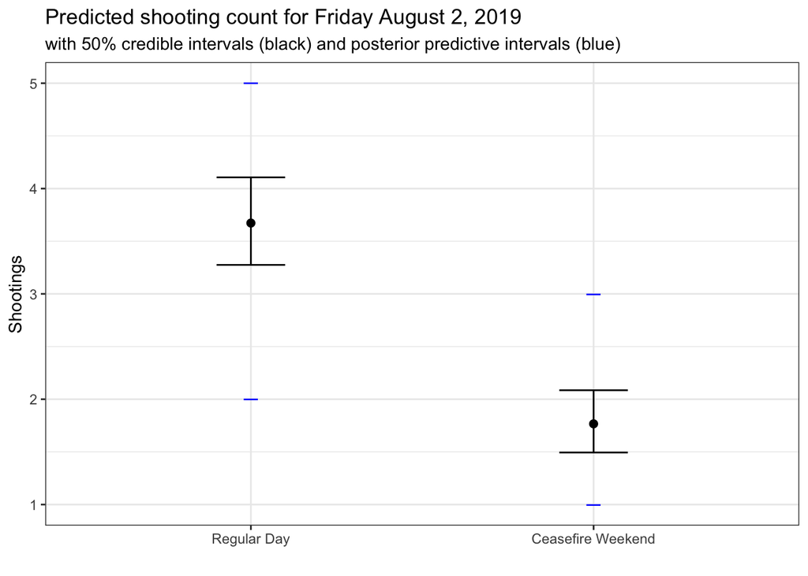

```r
### Ceasefire plot
pred.day <- as.Date("2019-08-02")
ceasefire.frame <- with(daily,
                  data.frame(
                    jul=julian(pred.day)[1],
                    weekday="Friday",
                    mothers.day = 0,
                    ceasefire=factor(c("Regular Day",
                                "Ceasefire Weekend"),
                                levels=c("Regular Day",
                                         "Ceasefire Weekend")),
                    day.of.year=yday(pred.day),
                    seasonal= yday(pred.day)))

post <- posterior_linpred(model,
                          newdata=ceasefire.frame,
                          transform=TRUE)
ceasefire.frame$Estimate <- apply(post,2, median)

# 95% CI
ci <- apply(post,2,function(x){quantile(x, prob=c(.25, .75))})
ceasefire.frame$low <- ci["25%",]
ceasefire.frame$high <- ci["75%",]

# 50% posterior predictive interval for main plot
preds <- posterior_predict(model,
                          newdata=ceasefire.frame,
                          transform=TRUE)

ceasefire.frame$high.ppd <- apply(preds,2,function(x){quantile(x, prob=c(.75), na.rm=T)})
ceasefire.frame$low.ppd <- apply(preds,2,function(x){quantile(x, prob=c(.25), na.rm=T)})


ceasefire.frame %>%
  ggplot() +
  aes(x=ceasefire, y=Estimate) +
  geom_point(aes(y = low.ppd), col="blue", shape=95, size=5) +
  geom_point(aes(y = high.ppd), col="blue", shape=95, size=5) +
  geom_point(aes(y = Estimate),
             size=2) +
  geom_errorbar(aes(ymin=low, ymax=high),
                width=.2) +

  xlab("") +
  ylab("Shootings") +
  ggtitle("Predicted shooting count for Friday August 2, 2019",
          subtitle="with 50% credible intervals (black) and posterior predictive intervals (blue)") +
  theme_bw()
```

Without a ceasefire, we'd expect about four people to get shot on this day. But because this will be a Ceasefire weekend, the model expects about half that many to be shot.

Notice the little blue horizontal lines drawn at 1 and 3 for the ceasefire weekend estimate. Those marks are the 50% posterior predictive intervals, representing the 50% window for the number of shootings you can expect on any given day. The fact that the lower tick mark rests at 1 and 3 means that there will be 0 shootings on a ceasefire day about 25% of the time, and >3 shootings about 25% of the time.

The ceasefire impact is real and at the same time, our model won’t be surprised by the occurrence of several shootings on each day of ceasefire weekend.

## Is it possible that violence is simply postponed?

Some people have suggested the possibility that people who decide not to commit shootings during ceasefire may simply postpone that violence until after ceasefire is over. This is possible, but seems unlikely given that lapses in violence observed during Ceasefires have been observed to extend beyond them, with one Ceasefire marking the beginning of [a 12-day period of zero shooting deaths](https://www.baltimoresun.com/news/maryland/crime/bs-md-ci-ceasefire-anniversary-20180731-story.html).

We can test the hypothesis of postponed violence by looking at the pattern of shootings observed in the three days following each three-day ceasefire weekend. We start by creating a dummy variable for these three-day periods following each ceasefire.

```r
# Get the three days following ceasefire (by incrementing the ceasefire friday dates by 3)
ceasefire.mondays <-
  as.Date(
  c("08/04/2017",
    "11/03/2017",
    "02/02/2018",
    "05/11/2018",
    "08/03/2018",
    "11/02/2018",
    "02/01/2019",
    "05/10/2019"),
      format="%m/%d/%Y") + 3

following.ceasefire <-
  lapply(ceasefire.mondays,
         function(x){
           seq(from=x,
               by="day",
               length.out=3)
           }
         )
following.ceasefire <- do.call("c",
                              following.ceasefire)

# mark days according to whether or not they're in the three days following ceasefire
daily$postceasefire <- ifelse(daily$CrimeDate %in% following.ceasefire, 1, 0)
```

We can now include this dummy variable in our larger model to test whether the three days following ceasefires show increased gun violence.

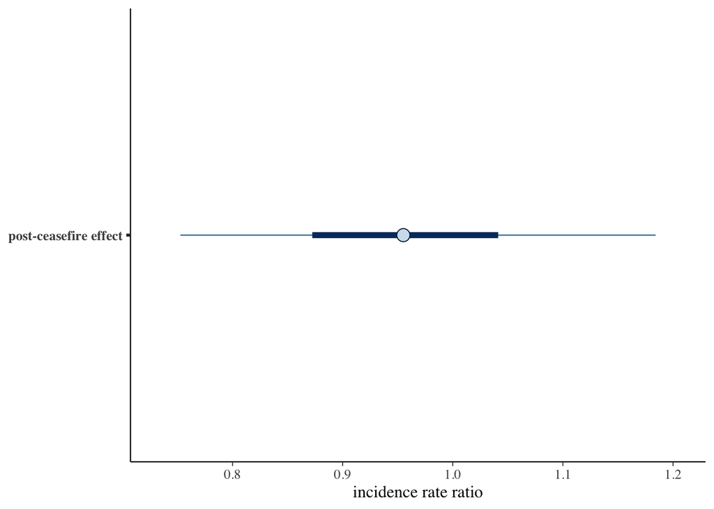

```r
model.two <- update(model, . ~ . + postceasefire, iter=1000) # three days post ceasefire indicator

post.ceasefire.effect <- as.array(model.two, regex_pars = "postceasefire")
# scale to an IRR by exponentiating
post.ceasefire.effect <- exp(post.ceasefire.effect)
mcmc_intervals(post.ceasefire.effect) +
  scale_y_discrete(labels="post-ceasefire effect") +
  xlab("incidence rate ratio")
```

```r
round(quantile(post.ceasefire.effect, probs=c(.025,.5,.975)), 2)
```

```
##  2.5%   50% 97.5%
##  0.72  0.96  1.23
```

The model does **not** suggest a higher number of shootings in the days following ceasefires. If anything there is a continued decrease (IRR=0.96, 95%CI: 0.72-1.23).